# Iniciando a brincadeira com R

Matheus Sampaio

Sunday, October 19, 2014

### Questão 1

> Assista [esse vídeo](https://www.google.com/url?q=https%3A%2F%2Fwww.ted.com%2Fplaylists%2F56%2Fmaking_sense_of_too_much_data&sa=D&sntz=1&usg=AFQjCNHqXjveHlVueeoGc1_XzcGc6dfPfw) com atenção. Perceba que a grande pergunta que Hans Rosling tenta responder é: temos dois mundos separados; o mundo ocidental norte rico e o resto do mundo pobre? Talvez você precise pausar o vídeo para entender, assistir mais de uma vez, etc.

Ele começa demostrando que as ideias preconcebidas influenciam no julgamento dos alunos. Em seguida ele mostra (através de um gráfico de bolhas) que nos anos 60 a ideia dos alunos sobre os países “em Desenvolvimento” poderia estar certa, porém já não se aplica ao ano de 2003. Hans analisa os dados sobre a distribuição de renda no mundo, onde demostra que aos poucos as pessoas estão saindo da faixa de pobreza.  
Hans mostra os dados sobre a mortalidade infantil, onde chega a concluir que um pais mais rico possui uma mortalidade infantil menor, porém é preciso investir bastante. Em seguida ele comenta que os países podem ser “quebrados” em partes menores para que se possam analisar melhor e formar estratégias melhores, como por exemplo definir uma estratégia para combater a mortalidade infantil para a população pobre e outra estratégia para a população rica.  
Comenta que dados como os apresentados são muito importantes e que vários deles estão sendo coletados. Porém ainda existe um trabalho a ser feito para que tais dados fiquem totalmente disponíveis. Onde ele mostra que a China está chegando perto da USA.

### Questão 2

> Qual o panorama geral dos profissionais de TI no Brasil sem ainda se preocupar com seus salários, apenas com sua localização, função, expertise…?

A maioria dos profissionais de TI do Brasil estão na iniciativa privada e trabalhando na região Sudeste do Brasil, principalmente em Belo Horizonte. Metade dos profissionais atuantes não possuem uma Pós Graduação ou uma Certificação.

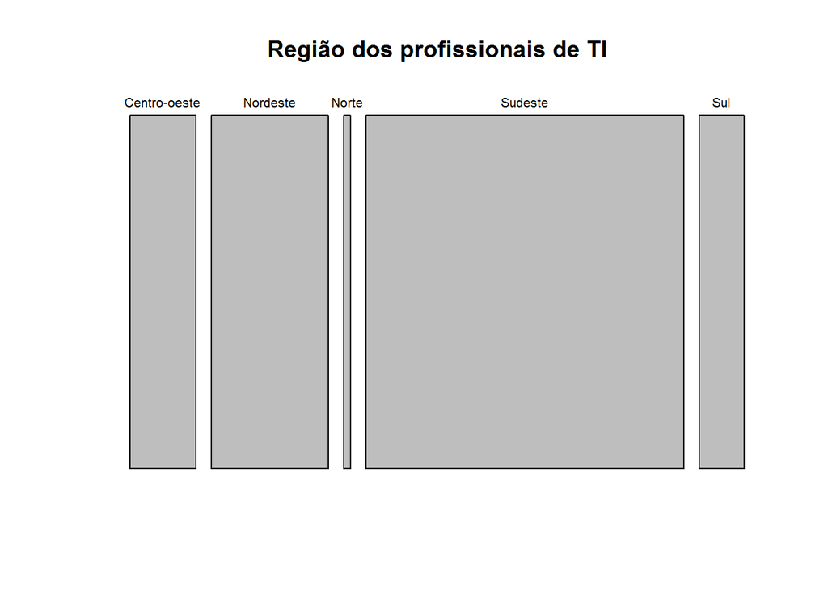

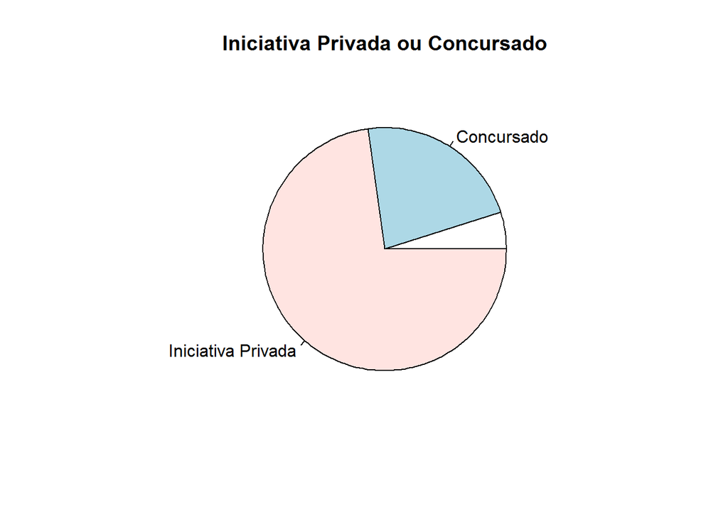

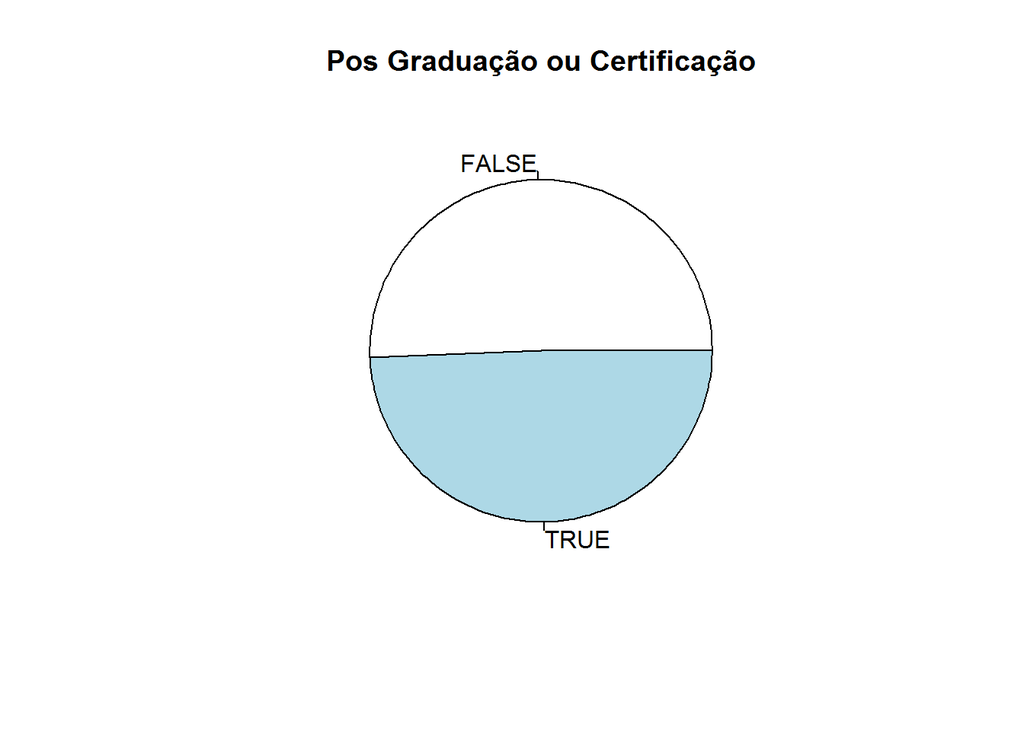

### Questão 3

> Os salários estão bem distribuídos no intervalo que vai do menor salário para o maior salário? Ou será que os salários são muito concentrados em um intervalo pequeno de valores? Será que existem salários atípicos (outliers)?

```
##    Min. 1st Qu.  Median    Mean 3rd Qu.    Max.
##     500    2281    3583    4233    5332   42120
```

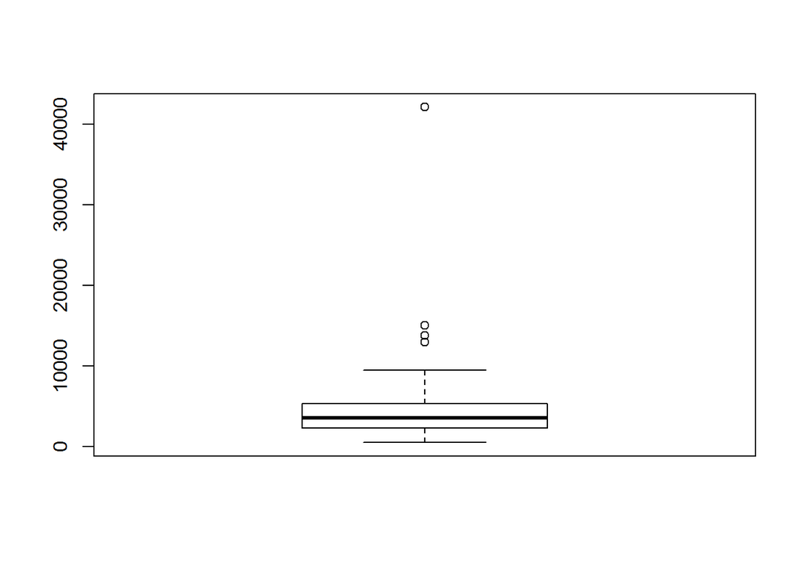

### Questão 4

> A distribuição que você encontrou é a que você esperava sem olhar os dados? Se não é, você tem alguma suspeita da razão para a diferença?

Não, já que eu esperava um intervalo de salário mais alto. O fato de vários profissionais não terem formação acadêmica deve ter influenciado negativamente no valor dos salários.

### Questão 5

> É interessante ver a média (mean) salarial para cada região. Como resultado, apresente uma tabela com o nome da região e a sua média salarial ordenada da região com a maior média salarial para a menor. Se você tivesse usado a mediana (median) em vez da média como métrica de interesse, o resultado seria o mesmo? Analise a situação e justifique. Aproveite e salve esta tabela em um arquivo do tipo csv.

```
## Centro-oeste     Nordeste      Sudeste          Sul        Norte
##     5620.474     4565.706     3962.227     3657.538     2552.500
```

Podemos ver abaixo como ficaria a tabela se tivesse usado a mediana.

```
## Centro-oeste      Sudeste          Sul     Nordeste        Norte
##      5000.00      3582.95      3500.00      2900.00      2552.50
```

Podemos observar que o Nordeste “caiu” para quarto lugar. Isso se deve ao fato dos salários dos outros estados estarem mais agrupados e não terem grandes outliers como o caso do profissional que tem um salário de 42 mil no Nordeste.

Para salvar o CSV:

```r
mean_salario = sort(tapply(salarios.ti.regioes$Salario.Bruto, salarios.ti.regioes$Regiao, mean), decreasing=TRUE)
write.csv(mean_salario, "C:\\Users\\matheus\\git\\analise-dados-2-p1\\data.csv")
```

### Questão 6

> Se um profissional de TI deseja ter um salario melhor, qual a(s) dica(s) para ele?

```
##     Nordeste Centro-oeste      Sudeste          Sul
##      9840.70      7100.75      5865.00      4669.60
```

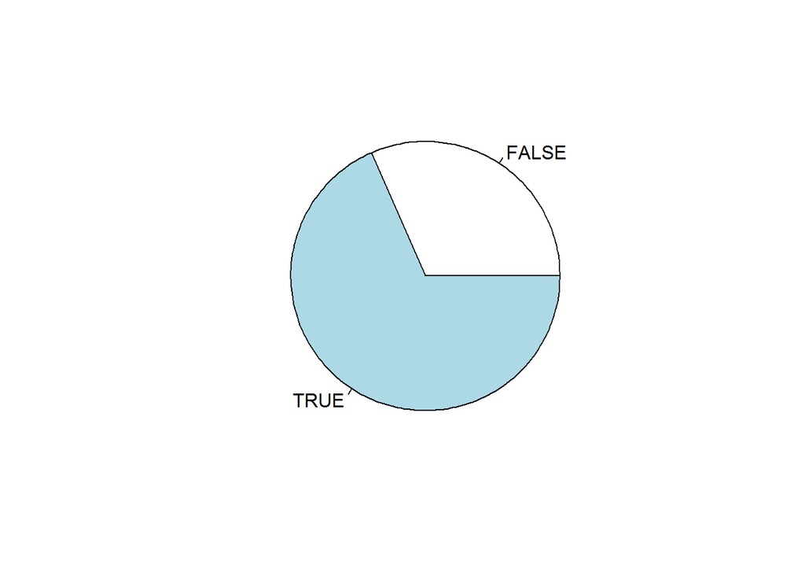

```
##                            Concursado Iniciativa Privada
##           6600.000           5573.545           5380.000
```